# Part 5 - Working with Time Series Data

# Table of Contents

In the previous notebook, we learned how to be more productive with **[Pandas](https://pandas.pydata.org/)** by using sophisticated multi-level indexing, aggregating and combining data. In this notebook, we will explore the capabilities for working with Time Series data. We will start with the default `datetime` object in Python and then jump to data structures for working with time series data in Pandas. Let's dive into the details.

```python
# Import libraries
import pandas as pd
import numpy as np
```

**Time Series** are one of the most common types of structured data that we encounter in daily life. Stock prices, weather data, energy usage, and even digital health, are all examples of data that can be collected at different time intervals. **Pandas** was developed in the context of financial modeling, so it contains an extensive set of tools for working with dates, times, and time-indexed data. Date and Time data comes in various flavors such as:

- **Timestamps:** for specific instants in time such as November 5th, 2020 at 7:00am
- **Fixed periods:** such as the month November 2010 or the full year 2020
- **Intervals of time:** length of time between a particular beginning and end point
- **Time deltas:** reference an exact length of time such as a duration of 30.5 seconds

In this notebook, we will briefly introduce date and time data types in native python and then focus on how to work with date/time data in Pandas.

## Date and Time in Python

Python's basic objects for working with time series data reside in the **`datetime`** module. Let's look at some examples.

```python
# Import datetime
from datetime import datetime
```

### Building `datetime` object

`datetime` objects can be used to quickly perform a host of useful functionalities. A date can be built in various ways and then properties of a `datetime` object can be used to get specific date and time details from it.

```python
# Build a date
now = datetime.now()
now
```

```
datetime.datetime(2020, 11, 25, 13, 23, 22, 106620)
```

`datetime.now()` creates a `datetime` object with current date and time down to the microsecond.

```python
# Get date and time details from current date
print('Year: ', now.year)
print('Month: ', now.month)
print('Day: ', now.day)
print('Hour: ', now.hour)
print('Minutes: ', now.minute)
print('Seconds: ', now.second)
print('Microsecond: ', now.microsecond)
```

```
Year:  2020
Month:  11
Day:  25
Hour:  13
Minutes:  23
Seconds:  22
Microsecond:  106620
```

A `datetime` object can also be created by specifying year, month, day, and other details.

```python
datetime(year=2020, month=9, day=10)
```

```
datetime.datetime(2020, 9, 10, 0, 0)
```

```python
datetime(year=2020, month=9, day=10, hour=11, minute=30)
```

```
datetime.datetime(2020, 9, 10, 11, 30)
```

### Converting between String and DateTime

`strftime` and `strptime` methods can be used to format `datetime` objects and pandas `Timestamp` objects (discussed later in this section).

- `strftime` - convert object to a string according to a given format
- `strptime` - parse a string into a `datetime` object given a corresponding format

#### Using `strftime` and `strptime`

**`strftime`** can be used to convert a `datetime` object to a string according to a given format. Standard string format codes for printing dates can read about in the [strftime](https://docs.python.org/3/library/datetime.html#strftime-and-strptime-behavior) section of Python's [datetime](https://docs.python.org/3/library/datetime.html) documentation.

```python
# print data
now
```

```
datetime.datetime(2020, 11, 25, 13, 23, 22, 106620)
```

```python
# apply strftime

print(now.strftime('%Y-%m-%d'))
print(now.strftime('%F'))
print(now.strftime('%D'))
print(now.strftime('%B %d, %Y'))
print(now.strftime('%d %b, %Y'))
print(now.strftime('%A'))
```

```
2020-11-25
2020-11-25
11/25/20
November 25, 2020
25 Nov, 2020
Wednesday
```

```python
# Check type
print(type(now.strftime('%Y-%m-%d')))
```

```
<class 'str'>
```

Similarly, **`strptime`** can be used to parse a string into a `datetime` object.

```python
xmas_day = '2020-12-25'
datetime.strptime(xmas_day, '%Y-%m-%d')
```

```
datetime.datetime(2020, 12, 25, 0, 0)
```

```python
random_day = '20200422T203448'
datetime.strptime(random_day, '%Y%m%dT%H%M%S')
```

```
datetime.datetime(2020, 4, 22, 20, 34, 48)
```

While `datetime.strptime` is a good way to parse a date when a format is known, it can be annoying to write a format each time.

#### Using `parser.parse`

`dateutil` module provides the `parser.parse` method that can parse dates from a variety of string formats.

```python
# Import parse
from dateutil.parser import parse
```

```python
# Parse various strings
xmas_day = '2020-12-25'
ind_day = '4th of July, 2015'
random_day = 'Nov 05, 2020 10:45 PM'
random_day2 = '20200422T203448'

print(parse(xmas_day))
print(parse(ind_day))
print(parse(random_day))
print(parse(random_day2))
```

```
2020-12-25 00:00:00
2015-07-04 00:00:00
2020-11-05 22:45:00
2020-04-22 20:34:48
```

```python
# Check type
print(type(parse(xmas_day)))
```

```
<class 'datetime.datetime'>
```

## Date and Time in Pandas

**Pandas** provides the following fundamental data structures for working with time series data:

- `Timestamp` type for working with time stamps. A replacement for Python's native `datetime`, it is based on the more efficient numpy.datetime64 data type. The associated Index structure is `DatetimeIndex`
- `Period` type for working with time Periods. The associated index structure is `PeriodIndex`
- `Timedelta` type for working with time deltas or durations. The associated index structure is `TimedeltaIndex`

### The Basics

**Pandas** provides a **`Timestamp`** object, which combines the ease of `datetime` and `dateutil` with the efficient storage of `numpy.datetime64`. The **`to_datetime`** method parses many different kinds of date representations returning a `Timestamp` object.

Passing a single date to `to_datetime` returns a `Timestamp`.

```python
# Create timestamp object
ind_day = pd.to_datetime('4th of July, 2020')
ind_day
```

```
Timestamp('2020-07-04 00:00:00')
```

`strftime` can be used to convert this object to a string according to a given format.

```python
# Get full name of Month using strftime
ind_day.strftime('%B')
```

```
'July'
```

#### `DatetimeIndex`

Passing a series of dates by default returns a **`DatetimeIndex`** which can be used to index data in a `Series` or `DataFrame`.

```python
dates = pd.to_datetime([datetime(2020, 12, 25), '4th of July, 2020',
                       '2018-Oct-6', '07-07-2017', '20200508', '20200422T203448'])
dates
```

```
DatetimeIndex(['2020-12-25 00:00:00', '2020-07-04 00:00:00',
               '2018-10-06 00:00:00', '2017-07-07 00:00:00',
               '2020-05-08 00:00:00', '2020-04-22 20:34:48'],
              dtype='datetime64[ns]', freq=None)
```

`DatetimeIndex` objects do not have a frequency (hourly, daily, monthly etc.) by default, as they are just snapshots in time. As a result, arithmetic operations such as addition, subtraction, or multiplication cannot be performed directly.

Pandas also supports converting integer or float **[epoch times](https://en.wikipedia.org/wiki/Unix_time)** to `Timestamp` and `DatetimeIndex`. The default unit is nanoseconds, since that is how `Timestamp` objects are stored internally.

```python
# Create Timestamp
pd.to_datetime(1349720105)
```

```
Timestamp('1970-01-01 00:00:01.349720105')
```

```python
# Create DatetimeIndex with seconds
pd.to_datetime([1349720105, 1349806505, 1349892905,
               1349979305, 1350065705], unit='s')
```

```
DatetimeIndex(['2012-10-08 18:15:05', '2012-10-09 18:15:05',
               '2012-10-10 18:15:05', '2012-10-11 18:15:05',
               '2012-10-12 18:15:05'],
              dtype='datetime64[ns]', freq=None)
```

Notice that the date values change based on the unit specified.

```python
# Create DatetimeIndex with milliseconds
pd.to_datetime([1349720105, 1349806505, 1349892905,
               1349979305, 1350065705], unit='ms')
```

```
DatetimeIndex(['1970-01-16 14:55:20.105000', '1970-01-16 14:56:46.505000',
               '1970-01-16 14:58:12.905000', '1970-01-16 14:59:39.305000',
               '1970-01-16 15:01:05.705000'],
              dtype='datetime64[ns]', freq=None)
```

```python
pd.to_datetime([1349720105, 1349806505, 1349892905,
               1349979305, 1350065705], unit='ns')
```

```
DatetimeIndex(['1970-01-01 00:00:01.349720105',
               '1970-01-01 00:00:01.349806505',
               '1970-01-01 00:00:01.349892905',
               '1970-01-01 00:00:01.349979305',
               '1970-01-01 00:00:01.350065705'],
              dtype='datetime64[ns]', freq=None)
```

#### `PeriodIndex`

A Timestamp represents a point in time, whereas a Period represents an interval in time. Time Periods can be used to check if a specific event occurs within a certain period, such as when monitoring the number of flights taking off or the average stock price during a period.

A `DatetimeIndex` object can be converted to a **`PeriodIndex`** using the **`to_period()`** function by specifying a frequency (such as `D` to indicate daily frequency).

```python
# Create daily time periods
period_daily = dates.to_period('D')
period_daily
```

```
PeriodIndex(['2020-12-25', '2020-07-04', '2018-10-06', '2017-07-07',
             '2020-05-08', '2020-04-22'],
            dtype='period[D]', freq='D')
```

Since a period represents a time interval, it has a `start_time` and an `end_time`.

```python
# Start time of a Period
period_daily.start_time
```

```
DatetimeIndex(['2020-12-25', '2020-07-04', '2018-10-06', '2017-07-07',
               '2020-05-08', '2020-04-22'],
              dtype='datetime64[ns]', freq=None)
```

```python
# End time of a Period
period_daily.end_time
```

```
DatetimeIndex(['2020-12-25 23:59:59.999999999',
               '2020-07-04 23:59:59.999999999',
               '2018-10-06 23:59:59.999999999',
               '2017-07-07 23:59:59.999999999',
               '2020-05-08 23:59:59.999999999',
               '2020-04-22 23:59:59.999999999'],
              dtype='datetime64[ns]', freq=None)
```

Note that the `start_time` and `end_time` are `DatetimeIndex` objects because the start and end times are just a snapshot in time of the time period.

To reiterate the concept, let's look at another example.

```python
# Create time period
p1 = pd.Period('2020-12-25')
print('Period is: ', p1)

# Create time stamp
t1 = pd.Timestamp('2020-12-25 18:12')
print('Timestamp is: ', t1)

# Test Time interval
p1.start_time < t1 < p1.end_time
```

```
Period is:  2020-12-25
Timestamp is:  2020-12-25 18:12:00
```

```
True
```

Since `Period` is an interval of time, the test returns `True` showing that `Timestamp` lies within the time interval.

##### Arithmetic Operations

Now that a frequency is associated with the object, various **arithmetic operations** can be performed.

```python
# Subtract 30 days
period_daily - 30
```

```
PeriodIndex(['2020-11-25', '2020-06-04', '2018-09-06', '2017-06-07',
             '2020-04-08', '2020-03-23'],
            dtype='period[D]', freq='D')
```

```python
# Add 10 days
period_daily + 10
```

```
PeriodIndex(['2021-01-04', '2020-07-14', '2018-10-16', '2017-07-17',
             '2020-05-18', '2020-05-02'],
            dtype='period[D]', freq='D')
```

Similarly, we can create time periods with monthly frequency and perform arithmetic operations.

```python
# Create monthly frequency
period_monthly = dates.to_period('M')
period_monthly
```

```
PeriodIndex(['2020-12', '2020-07', '2018-10', '2017-07', '2020-05', '2020-04'], dtype='period[M]', freq='M')
```

```python
# Subtract 12 months
period_monthly - 12
```

```
PeriodIndex(['2019-12', '2019-07', '2017-10', '2016-07', '2019-05', '2019-04'], dtype='period[M]', freq='M')
```

```python
# Add 10 months
period_monthly + 10
```

```
PeriodIndex(['2021-10', '2021-05', '2019-08', '2018-05', '2021-03', '2021-02'], dtype='period[M]', freq='M')
```

#### `TimedeltaIndex`

Time deltas represent the temporal difference between two `datetime` objects. Time deltas come in handy when you need to calculate the difference between two dates. A **`TimedeltaIndex`** can be easily created by subtracting a date from `dates`.

```python
# Subtract a specific date from dates
dates - pd.to_datetime('2020-05-15')
```

```
TimedeltaIndex([   '224 days 00:00:00',     '50 days 00:00:00',
                 '-587 days +00:00:00', '-1043 days +00:00:00',
                   '-7 days +00:00:00',   '-23 days +20:34:48'],
               dtype='timedelta64[ns]', freq=None)
```

```python
# Subtract date using index
dates - dates[3]
```

```
TimedeltaIndex(['1267 days 00:00:00', '1093 days 00:00:00',
                 '456 days 00:00:00',    '0 days 00:00:00',
                '1036 days 00:00:00', '1020 days 20:34:48'],
               dtype='timedelta64[ns]', freq=None)
```

### Date Range and Frequency

Regular date sequences can be created using functions, such as `pd.date_range()` for timestamps, `pd.period_range()` for periods, and `pd.timedelta_range()` for time deltas. For many applications, this is sufficient. Fixed frequency, such as daily, monthly, or every 15 minutes, are often desirable. **Pandas** provides a full suite of standard time series frequencies found [here](https://pandas.pydata.org/pandas-docs/stable/user_guide/timeseries.html#dateoffset-objects).

- **Create a Sequence of Dates** - by default, the frequency is daily. Both the start and end dates are included in the result.

```python
pd.date_range('2020-08-03', '2020-08-10')
```

```
DatetimeIndex(['2020-08-03', '2020-08-04', '2020-08-05', '2020-08-06',
               '2020-08-07', '2020-08-08', '2020-08-09', '2020-08-10'],
              dtype='datetime64[ns]', freq='D')
```

- **Sequence of Dates with Period** - alternatively, a date range can be specified with a startpoint and a number of periods.

```python
dt_rng = pd.date_range('2020-08-03', periods=8)
dt_rng
```

```
DatetimeIndex(['2020-08-03', '2020-08-04', '2020-08-05', '2020-08-06',
               '2020-08-07', '2020-08-08', '2020-08-09', '2020-08-10'],
              dtype='datetime64[ns]', freq='D')
```

Note that the output when using `date_range()` is a `DatetimeIndex` object where each date is a snapshot in time (`Timestamp`).

```python
dt_rng[0]
```

```
Timestamp('2020-08-03 00:00:00', freq='D')
```

- **Changing the Frequency** - the frequency can be modified by altering the `freq` argument. **Pandas** provides a full suite of standard time series frequencies found [here](https://pandas.pydata.org/pandas-docs/stable/user_guide/timeseries.html#dateoffset-objects).

```python
# Date range with Hourly Frequency
pd.date_range('2020-08-03', periods=8, freq='H')
```

```
DatetimeIndex(['2020-08-03 00:00:00', '2020-08-03 01:00:00',
               '2020-08-03 02:00:00', '2020-08-03 03:00:00',
               '2020-08-03 04:00:00', '2020-08-03 05:00:00',
               '2020-08-03 06:00:00', '2020-08-03 07:00:00'],
              dtype='datetime64[ns]', freq='H')
```

```python
# Date range with Month Start Frequency
pd.date_range('2020-02-03', periods=8, freq='MS')
```

```
DatetimeIndex(['2020-03-01', '2020-04-01', '2020-05-01', '2020-06-01',
               '2020-07-01', '2020-08-01', '2020-09-01', '2020-10-01'],
              dtype='datetime64[ns]', freq='MS')
```

- **Create a Sequence of Periods**

```python
# Period Range with Monthly Frequency
pd.period_range('2020-02-03', periods=8, freq='M')
```

```
PeriodIndex(['2020-02', '2020-03', '2020-04', '2020-05', '2020-06', '2020-07',
             '2020-08', '2020-09'],
            dtype='period[M]', freq='M')
```

`pd.period_range()` generated eight periods with monthly frequency. Note that the output is a `PeriodIndex` object. As mentioned earlier, `Period` represents an interval in time, whereas `Timestamp` represents a point in time.

```python
prd_rng = pd.period_range('2020-02-03', periods=8, freq='D')
prd_rng
```

```
PeriodIndex(['2020-02-03', '2020-02-04', '2020-02-05', '2020-02-06',
             '2020-02-07', '2020-02-08', '2020-02-09', '2020-02-10'],
            dtype='period[D]', freq='D')
```

```python
# Print start and end times
print('Start time for period at 0 index: ', prd_rng[0].start_time)
print('End time for period at 0 index: ', prd_rng[0].end_time)
```

```
Start time for period at 0 index:  2020-02-03 00:00:00
End time for period at 0 index:  2020-02-03 23:59:59.999999999
```

- **Create a Sequence of Durations (Time Deltas)**

```python
# Time Deltas with daily frequency
pd.timedelta_range(start='1 day', periods=6)
```

```
TimedeltaIndex(['1 days', '2 days', '3 days', '4 days', '5 days', '6 days'], dtype='timedelta64[ns]', freq='D')
```

```python
# Time deltas with hourly frequency
pd.timedelta_range(0, periods=8, freq='H')
```

```
TimedeltaIndex(['00:00:00', '01:00:00', '02:00:00', '03:00:00', '04:00:00',
                '05:00:00', '06:00:00', '07:00:00'],
               dtype='timedelta64[ns]', freq='H')
```

```python
# Time deltas with a 6 hour frequency
pd.timedelta_range(start='1 day', end='3 days', freq='6H')
```

```
TimedeltaIndex(['1 days 00:00:00', '1 days 06:00:00', '1 days 12:00:00',
                '1 days 18:00:00', '2 days 00:00:00', '2 days 06:00:00',
                '2 days 12:00:00', '2 days 18:00:00', '3 days 00:00:00'],
               dtype='timedelta64[ns]', freq='6H')
```

#### Combining Frequency Codes

**Frequency codes** can also be combined with numbers to specify other frequencies. For example, a frequency of 1 hour and 30 minutes can be created by combining the hour `H` and minute `T` codes.

```python
pd.date_range('2020-08-03', periods=10, freq='1H30T')
```

```
DatetimeIndex(['2020-08-03 00:00:00', '2020-08-03 01:30:00',
               '2020-08-03 03:00:00', '2020-08-03 04:30:00',
               '2020-08-03 06:00:00', '2020-08-03 07:30:00',
               '2020-08-03 09:00:00', '2020-08-03 10:30:00',
               '2020-08-03 12:00:00', '2020-08-03 13:30:00'],
              dtype='datetime64[ns]', freq='90T')
```

Similarly, a frequency of 1 day 5 hours and 30 mins can be created by combining the day `D`, hour `H` and minute `T` codes. As an example, we will create a `timedelta_range`.

```python
pd.timedelta_range(0, periods=10, freq='1D5H30T')
```

```
TimedeltaIndex([ '0 days 00:00:00',  '1 days 05:30:00',  '2 days 11:00:00',
                 '3 days 16:30:00',  '4 days 22:00:00',  '6 days 03:30:00',
                 '7 days 09:00:00',  '8 days 14:30:00',  '9 days 20:00:00',
                '11 days 01:30:00'],
               dtype='timedelta64[ns]', freq='1770T')
```

### Indexing and Selection

Pandas time series tools provide the ability to use dates and times as indices to organize data. This allows for the benefits of indexed data, such as automatic alignment, data slicing, and selection etc.

Pandas was developed with a financial context, so it includes some very specific tools for financial data. The `pandas-datareader` package (installable via `conda install pandas-datareader`) can import financial data from a number of available sources. Here, we will load [stock price data for GE](https://finance.yahoo.com/quote/GE/) as an example.

```python
# Get stock data
from pandas_datareader import data

ge = data.DataReader('GE', start='2010', end='2021',
                       data_source='yahoo')
ge.head()
```

| Date | High | Low | Open | Close | Volume | Adj Close |
| --- | --- | --- | --- | --- | --- | --- |
| 2010-01-04 | 15.038462 | 14.567307 | 14.634615 | 14.855769 | 69763000.0 | 10.840267 |
| 2010-01-05 | 15.067307 | 14.855769 | 14.865385 | 14.932693 | 67132600.0 | 10.896401 |
| 2010-01-06 | 15.019231 | 14.846154 | 14.932693 | 14.855769 | 57683400.0 | 10.840267 |
| 2010-01-07 | 15.846154 | 14.836538 | 14.884615 | 15.625000 | 192891100.0 | 11.401575 |
| 2010-01-08 | 16.048077 | 15.644231 | 15.682693 | 15.961538 | 119717100.0 | 11.647147 |

```python
# Check data type
ge.index.dtype
```

```
dtype('<M8[ns]')
```

Pandas stores timestamps using NumPy’s `datetime64` data type at the nanosecond level. Scalar values from a `DatetimeIndex` are pandas `Timestamp` objects.

```python
# Check data type
ge.index[0]
```

```
Timestamp('2010-01-04 00:00:00')
```

- Select Data for Specific Date

```python
ge.loc['2015-07-06',:]
```

```
High         2.561539e+01
Low          2.519231e+01
Open         2.550961e+01
Close        2.529808e+01
Volume       2.897240e+07
Adj Close    2.216700e+01
Name: 2015-07-06 00:00:00, dtype: float64
```

- Dates can be specified in different formats as follows:

```python
print(ge.loc['07/06/2015',:])
print(ge.loc['20150706',:])
print(ge.loc[datetime(2015, 7, 6),:])
```

```
High         2.561539e+01
Low          2.519231e+01
Open         2.550961e+01
Close        2.529808e+01
Volume       2.897240e+07
Adj Close    2.216700e+01
Name: 2015-07-06 00:00:00, dtype: float64
High         2.561539e+01
Low          2.519231e+01
Open         2.550961e+01
Close        2.529808e+01
Volume       2.897240e+07
Adj Close    2.216700e+01
Name: 2015-07-06 00:00:00, dtype: float64
High         2.561539e+01
Low          2.519231e+01
Open         2.550961e+01
Close        2.529808e+01
Volume       2.897240e+07
Adj Close    2.216700e+01
Name: 2015-07-06 00:00:00, dtype: float64
```

- Partial string indexing allows for selection using just the year or month

```python
# Using year
ge.loc['2020']
```

| Date | High | Low | Open | Close | Volume | Adj Close |
| --- | --- | --- | --- | --- | --- | --- |
| 2020-01-02 | 11.96 | 11.23 | 11.23 | 11.93 | 87421800.0 | 11.880686 |
| 2020-01-03 | 12.00 | 11.53 | 11.57 | 11.97 | 85885800.0 | 11.920521 |
| 2020-01-06 | 12.21 | 11.84 | 11.84 | 12.14 | 111948700.0 | 12.089818 |
| 2020-01-07 | 12.24 | 11.92 | 12.15 | 12.05 | 70579300.0 | 12.000189 |
| 2020-01-08 | 12.05 | 11.87 | 11.99 | 11.94 | 55402500.0 | 11.890644 |
| ... | ... | ... | ... | ... | ... | ... |
| 2020-11-19 | 9.76 | 9.51 | 9.62 | 9.66 | 87177500.0 | 9.660000 |
| 2020-11-20 | 9.83 | 9.59 | 9.64 | 9.76 | 79923400.0 | 9.760000 |
| 2020-11-23 | 10.27 | 9.86 | 9.86 | 10.07 | 108197300.0 | 10.070000 |
| 2020-11-24 | 10.85 | 10.40 | 10.71 | 10.45 | 175891500.0 | 10.450000 |
| 2020-11-25 | 10.56 | 10.34 | 10.53 | 10.50 | 107645396.0 | 10.500000 |

229 rows × 6 columns

```python
# Using year-month
ge.loc['2020-10']
```

| Date | High | Low | Open | Close | Volume | Adj Close |
| --- | --- | --- | --- | --- | --- | --- |
| 2020-10-01 | 6.29 | 6.11 | 6.27 | 6.24 | 79175600.0 | 6.24 |
| 2020-10-02 | 6.40 | 6.05 | 6.05 | 6.39 | 90076400.0 | 6.39 |
| 2020-10-05 | 6.45 | 6.32 | 6.39 | 6.41 | 58283600.0 | 6.41 |
| 2020-10-06 | 6.58 | 6.11 | 6.43 | 6.17 | 170066200.0 | 6.17 |
| 2020-10-07 | 6.40 | 6.21 | 6.22 | 6.31 | 83286100.0 | 6.31 |
| 2020-10-08 | 6.67 | 6.34 | 6.36 | 6.65 | 103167300.0 | 6.65 |
| 2020-10-09 | 7.07 | 6.70 | 7.07 | 6.84 | 171507500.0 | 6.84 |
| 2020-10-12 | 6.92 | 6.74 | 6.92 | 6.83 | 89036400.0 | 6.83 |
| 2020-10-13 | 6.82 | 6.66 | 6.79 | 6.72 | 75287600.0 | 6.72 |
| 2020-10-14 | 6.89 | 6.72 | 6.72 | 6.82 | 98076200.0 | 6.82 |
| 2020-10-15 | 6.88 | 6.61 | 6.70 | 6.87 | 89252700.0 | 6.87 |
| 2020-10-16 | 7.35 | 6.94 | 6.96 | 7.29 | 169147300.0 | 7.29 |
| 2020-10-19 | 7.47 | 7.23 | 7.39 | 7.29 | 130837100.0 | 7.29 |
| 2020-10-20 | 7.42 | 7.27 | 7.35 | 7.34 | 98420100.0 | 7.34 |
| 2020-10-21 | 7.41 | 7.27 | 7.28 | 7.32 | 73811100.0 | 7.32 |
| 2020-10-22 | 7.75 | 7.32 | 7.33 | 7.72 | 95766900.0 | 7.72 |
| 2020-10-23 | 8.03 | 7.56 | 7.93 | 7.63 | 132563200.0 | 7.63 |
| 2020-10-26 | 7.56 | 7.28 | 7.46 | 7.38 | 104254400.0 | 7.38 |
| 2020-10-27 | 7.40 | 7.09 | 7.40 | 7.10 | 98170000.0 | 7.10 |
| 2020-10-28 | 7.86 | 7.41 | 7.51 | 7.42 | 253494100.0 | 7.42 |
| 2020-10-29 | 7.74 | 7.31 | 7.66 | 7.37 | 123298000.0 | 7.37 |
| 2020-10-30 | 7.54 | 7.29 | 7.34 | 7.42 | 102370100.0 | 7.42 |

- Timestamps can be sliced using the `:` notation

```python
# Slice using Dates
ge.loc['2020-05-04':'2020-05-12']
```

| Date | High | Low | Open | Close | Volume | Adj Close |
| --- | --- | --- | --- | --- | --- | --- |
| 2020-05-04 | 6.31 | 6.15 | 6.30 | 6.21 | 136852400.0 | 6.190472 |
| 2020-05-05 | 6.46 | 6.16 | 6.28 | 6.20 | 116998500.0 | 6.180502 |
| 2020-05-06 | 6.25 | 5.97 | 6.20 | 5.98 | 117253600.0 | 5.961195 |
| 2020-05-07 | 6.26 | 6.06 | 6.06 | 6.11 | 100663300.0 | 6.090786 |
| 2020-05-08 | 6.33 | 6.16 | 6.21 | 6.29 | 93934600.0 | 6.270220 |
| 2020-05-11 | 6.25 | 6.13 | 6.24 | 6.19 | 71843000.0 | 6.170535 |
| 2020-05-12 | 6.28 | 6.00 | 6.22 | 6.00 | 95652200.0 | 5.981132 |

```python
# Slice using year-month
ge.loc['2020-05':'2020-07']
```

| Date | High | Low | Open | Close | Volume | Adj Close |
| --- | --- | --- | --- | --- | --- | --- |
| 2020-05-01 | 6.74 | 6.41 | 6.67 | 6.50 | 120376500.0 | 6.479559 |
| 2020-05-04 | 6.31 | 6.15 | 6.30 | 6.21 | 136852400.0 | 6.190472 |
| 2020-05-05 | 6.46 | 6.16 | 6.28 | 6.20 | 116998500.0 | 6.180502 |
| 2020-05-06 | 6.25 | 5.97 | 6.20 | 5.98 | 117253600.0 | 5.961195 |
| 2020-05-07 | 6.26 | 6.06 | 6.06 | 6.11 | 100663300.0 | 6.090786 |
| ... | ... | ... | ... | ... | ... | ... |
| 2020-07-27 | 6.85 | 6.69 | 6.84 | 6.71 | 70704000.0 | 6.698927 |
| 2020-07-28 | 6.96 | 6.69 | 6.70 | 6.89 | 76033600.0 | 6.878630 |
| 2020-07-29 | 7.00 | 6.52 | 6.99 | 6.59 | 148442400.0 | 6.579125 |
| 2020-07-30 | 6.51 | 6.26 | 6.50 | 6.26 | 127526900.0 | 6.249670 |
| 2020-07-31 | 6.29 | 6.00 | 6.25 | 6.07 | 142731700.0 | 6.059984 |

64 rows × 6 columns

### Resampling, Shifting, and Windowing

#### Resampling

The process of converting a time series from one frequency to another is called **Resampling**. When higher frequency data is aggregated to lower frequency, it is called **downsampling**, while converting lower frequency to higher frequency is called **upsampling**. For simplicity, we'll use just the closing price `Close` data.

```python
ge = ge['Close']
ge.head()
```

```
Date
2010-01-04    14.855769
2010-01-05    14.932693
2010-01-06    14.855769
2010-01-07    15.625000
2010-01-08    15.961538
Name: Close, dtype: float64
```

**Resampling** can be done using the `resample()` method, or the much simpler `asfreq()` method.

- `resample()`: is a data aggregation method. It is a flexible and high-performance method that can be used to process very large time series.
- `asfreq()`: is a data selection method.

We will **downsample** the data using 'business year end' frequency `BA` and create a plot of the data returned after applying the two functions.

```python
# Using resample()
ge.resample('BA').mean()
```

```
Date
2010-12-31    15.893658
2011-12-30    17.434333
2012-12-31    19.453038
2013-12-31    23.083371
2014-12-31    24.994277
2015-12-31    25.767819
2016-12-30    29.180174
2017-12-29    24.972418
2018-12-31    12.402774
2019-12-31     9.782701
2020-12-31     7.963930
Freq: BA-DEC, Name: Close, dtype: float64
```

```python
# Using asfreq()
ge.asfreq('BA')
```

```
Date
2010-12-31    17.586538
2011-12-30    17.221153
2012-12-31    20.182692
2013-12-31    26.951923
2014-12-31    24.298077
2015-12-31    29.951923
2016-12-30    30.384615
2017-12-29    16.778847
2018-12-31     7.278846
2019-12-31    11.160000
Freq: BA-DEC, Name: Close, dtype: float64
```

##### Downsample Plot

Plot the **down-sampled** data to compare the returned data of the two functions.

```python
# Import Plotting libraries
import matplotlib.pyplot as plt
%matplotlib inline
import seaborn; seaborn.set()
```

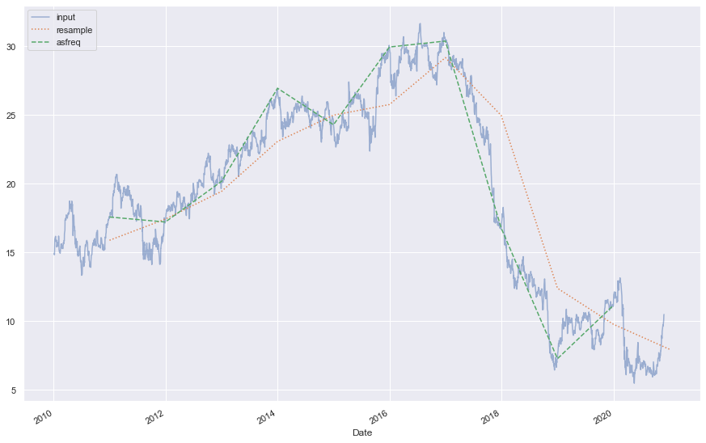

```python
# Plot data
plt.figure(figsize=(15,10))
ge.plot(alpha=0.5, style='-')
ge.resample('BA').mean().plot(style=':')
ge.asfreq('BA').plot(style='--');
plt.legend(['input', 'resample', 'asfreq'],
           loc='upper left');
```

We can see that at each point, `resample` returns the average of the previous year, as shown by the dotted line, while `asfreq` reports the value at the end of the year, as shown by dashed line.

**Upsampling** involves converting from a low frequency to a higher frequency where no aggregation is needed. `resample()` and `asfreq()` are largely equivalent in the case of upsampling. The default for both methods is to leave the up-sampled points empty (filled with NA values). The `asfreq()` method accepts arguments to specify how values are imputed.

We will subset the data and then upsample with daily `D` frequency.

```python
# Subset Data
ge_up_data = ge.iloc[:10]
ge_up_data
```

```
Date
2010-01-04    14.855769
2010-01-05    14.932693
2010-01-06    14.855769
2010-01-07    15.625000
2010-01-08    15.961538
2010-01-11    16.115385
2010-01-12    16.125000
2010-01-13    16.182692
2010-01-14    16.057692
2010-01-15    15.807693
Name: Close, dtype: float64
```

```python
# Upsample with Daily frequency
ge_up_data.asfreq('D')
```

```
Date
2010-01-04    14.855769
2010-01-05    14.932693
2010-01-06    14.855769
2010-01-07    15.625000
2010-01-08    15.961538
2010-01-09          NaN
2010-01-10          NaN
2010-01-11    16.115385
2010-01-12    16.125000
2010-01-13    16.182692
2010-01-14    16.057692
2010-01-15    15.807693
Freq: D, Name: Close, dtype: float64
```

The default is to leave the up-sampled points empty (filled with NA values). Forward `ffill` or Backward `bfill` methods can be used to impute missing values.

```python
# Using forward fill
ge_up_data.asfreq('D', method='ffill')
```

```
Date
2010-01-04    14.855769
2010-01-05    14.932693
2010-01-06    14.855769
2010-01-07    15.625000
2010-01-08    15.961538
2010-01-09    15.961538
2010-01-10    15.961538
2010-01-11    16.115385
2010-01-12    16.125000
2010-01-13    16.182692
2010-01-14    16.057692
2010-01-15    15.807693
Freq: D, Name: Close, dtype: float64
```

##### Upsample Plot

Plot the **up-sampled** data to compare the data returned from various fill methods.

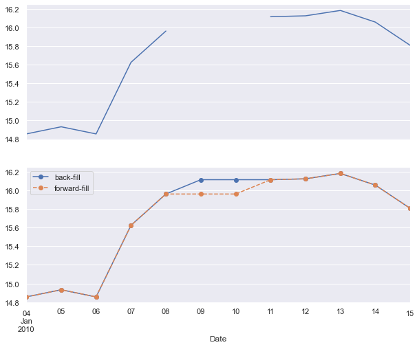

```python
fig, ax = plt.subplots(2, figsize=(10,8), sharex=True)
ge_up_data.asfreq('D').plot(ax=ax[0])

ge_up_data.asfreq('D', method='bfill').plot(ax=ax[1], style='-o')
ge_up_data.asfreq('D', method='ffill').plot(ax=ax[1], style='--o')
ax[1].legend(["back-fill", "forward-fill"]);
```

The top plot shows upsampled data using a daily frequency with default settings where non-business days are `NA` values that do not appear on the plot. The bottom plot shows forward and backward fill strategies for filling the gaps.

#### Shifting

A common use case of time series is shifting of data in time i.e. moving data backward and forward through time. Pandas includes `shift()` and `tshift()` methods for shifting data.

- **`shift()`** - shifts the data
- **`tshift()`** - shifts the index

In both cases, the shift is specified in multiples of the frequency. Let's look at some examples.

```python
# Print Data
ge_up_data
```

```
Date
2010-01-04    14.855769
2010-01-05    14.932693
2010-01-06    14.855769
2010-01-07    15.625000
2010-01-08    15.961538
2010-01-11    16.115385
2010-01-12    16.125000
2010-01-13    16.182692
2010-01-14    16.057692
2010-01-15    15.807693
Name: Close, dtype: float64
```

```python
# Shift Forward
ge_up_data.shift(2)
```

```
Date
2010-01-04          NaN
2010-01-05          NaN
2010-01-06    14.855769
2010-01-07    14.932693
2010-01-08    14.855769
2010-01-11    15.625000
2010-01-12    15.961538
2010-01-13    16.115385
2010-01-14    16.125000
2010-01-15    16.182692
Name: Close, dtype: float64
```

```python
# Shift Backward
ge_up_data.shift(-2)
```

```
Date
2010-01-04    14.855769
2010-01-05    15.625000
2010-01-06    15.961538
2010-01-07    16.115385
2010-01-08    16.125000
2010-01-11    16.182692
2010-01-12    16.057692
2010-01-13    15.807693
2010-01-14          NaN
2010-01-15          NaN
Name: Close, dtype: float64
```

Both *forward* and *backward* `shift()` opertions shift the data leaving the index unmodified. Let's look at how index is modified with `tshift()`.

```python
# Shift backward with Index
ge_up_data.tshift(-2)
```

```
Date
2009-12-31    14.855769
2010-01-01    14.932693
2010-01-04    14.855769
2010-01-05    15.625000
2010-01-06    15.961538
2010-01-07    16.115385
2010-01-08    16.125000
2010-01-11    16.182692
2010-01-12    16.057692
2010-01-13    15.807693
Freq: B, Name: Close, dtype: float64
```

##### Plot the Data

Let's look at another example of shifting data using `shift()` and `tshift()` to shift the `ge` data. We will plot the data to visualize the differences.

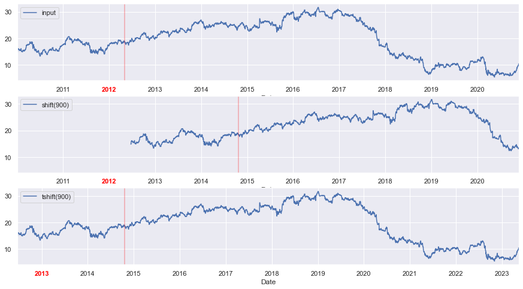

```python
fig, ax = plt.subplots(3, figsize=(15,8), sharey=True)

# apply a frequency to the data
ge = ge.asfreq('D', method='pad')

# shift the data
ge.plot(ax=ax[0])
ge.shift(900).plot(ax=ax[1])
ge.tshift(900).plot(ax=ax[2])

# legends and annotations
local_max = pd.to_datetime('2012-05-05')
offset = pd.Timedelta(900, 'D')

ax[0].legend(['input'], loc=2)
ax[0].get_xticklabels()[2].set(weight='heavy', color='red')
ax[0].axvline(local_max, alpha=0.3, color='red')

ax[1].legend(['shift(900)'], loc=2)
ax[1].get_xticklabels()[2].set(weight='heavy', color='red')
ax[1].axvline(local_max + offset, alpha=0.3, color='red')

ax[2].legend(['tshift(900)'], loc=2)
ax[2].get_xticklabels()[1].set(weight='heavy', color='red')
ax[2].axvline(local_max + offset, alpha=0.3, color='red');
```

The top panel in the plot shows `ge` data with a red line showing a local date. The middle panel shows the `shift(900)` operation which shifts the data by 900 days, leaving `NA` values at early indices. This is represented by the fact that there is no line on the plot for first 900 days. The bottom panel shows the `tshift(900)` operation, which shifts the index by 900 days, changing the start and end date ranges as shown.

#### Rolling Window

Rolling statistics are another time series specific operation where data is evaluated over a sliding window. Rolling operations are useful for smoothing noisy data. The `rolling()` operator behaves similarly to `resample` and `groupby` operations, but instead of grouping, it enables grouping over a sliding window.

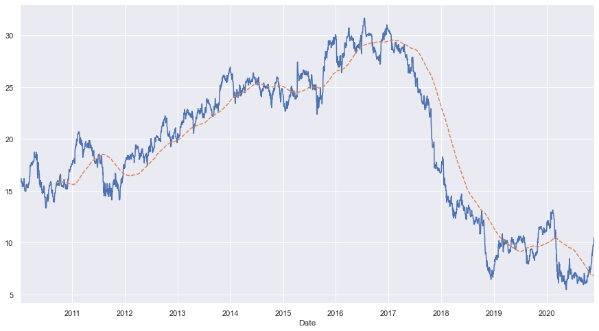

```python
plt.figure(figsize=(15,8))

# plot data
ge.plot()

# plot 250 day rolling mean
ge.rolling(250).mean().plot(style='--');
```

The plot shows GE stock price data. The **dashed line** represents 250-day moving window average of the stock price.

### Time Zones

We live in a global world where many companies operate in different time zones. This makes it crucial to carefully analyze the data based on the correct time zone. Many users work with time series in **UTC** (coordinated universal time) time which is the current international standard. Time zones are expressed as offsets from UTC; for example, California is seven hours behind UTC during daylight saving time (DST) and eight hours behind the rest of the year.

#### Localization and Conversion

Time series objects in Pandas do not have an assigned time zone by default. Let's consider the GE stock price `ge` data as an example.

```python
# print data
ge.head()
```

```
Date
2010-01-04    14.855769
2010-01-05    14.932693
2010-01-06    14.855769
2010-01-07    15.625000
2010-01-08    15.961538
Freq: D, Name: Close, dtype: float64
```

```python
# check timezone
print(ge.index.tz)
```

```
None
```

The index's `tz` field is `None`. We can assign a time zone using `tz_localize` method.

```python
# localize timezone
ge_utc = ge.tz_localize('UTC')
ge_utc.index
```

```
DatetimeIndex(['2010-01-04 00:00:00+00:00', '2010-01-05 00:00:00+00:00',
               '2010-01-06 00:00:00+00:00', '2010-01-07 00:00:00+00:00',
               '2010-01-08 00:00:00+00:00', '2010-01-09 00:00:00+00:00',
               '2010-01-10 00:00:00+00:00', '2010-01-11 00:00:00+00:00',
               '2010-01-12 00:00:00+00:00', '2010-01-13 00:00:00+00:00',
               ...
               '2020-11-16 00:00:00+00:00', '2020-11-17 00:00:00+00:00',
               '2020-11-18 00:00:00+00:00', '2020-11-19 00:00:00+00:00',
               '2020-11-20 00:00:00+00:00', '2020-11-21 00:00:00+00:00',
               '2020-11-22 00:00:00+00:00', '2020-11-23 00:00:00+00:00',
               '2020-11-24 00:00:00+00:00', '2020-11-25 00:00:00+00:00'],
              dtype='datetime64[ns, UTC]', name='Date', length=3979, freq='D')
```

Once a time series has been localized to a particular time zone, it can be easily converted to another time zone with `tz_convert`.

```python
ge_ny = ge_utc.tz_convert('America/New_York')
ge_ny.index
```

```
DatetimeIndex(['2010-01-03 19:00:00-05:00', '2010-01-04 19:00:00-05:00',
               '2010-01-05 19:00:00-05:00', '2010-01-06 19:00:00-05:00',
               '2010-01-07 19:00:00-05:00', '2010-01-08 19:00:00-05:00',
               '2010-01-09 19:00:00-05:00', '2010-01-10 19:00:00-05:00',
               '2010-01-11 19:00:00-05:00', '2010-01-12 19:00:00-05:00',
               ...
               '2020-11-15 19:00:00-05:00', '2020-11-16 19:00:00-05:00',
               '2020-11-17 19:00:00-05:00', '2020-11-18 19:00:00-05:00',
               '2020-11-19 19:00:00-05:00', '2020-11-20 19:00:00-05:00',
               '2020-11-21 19:00:00-05:00', '2020-11-22 19:00:00-05:00',
               '2020-11-23 19:00:00-05:00', '2020-11-24 19:00:00-05:00'],
              dtype='datetime64[ns, America/New_York]', name='Date', length=3979, freq='D')
```

**Epoch time** can be read as timezone-naive timestamps and then localized to the appropriate timezone using the `tz_localize` method.

```python
# Localize epoch as a timestamp with US/Pacific timezone
pd.Timestamp(1262347200000000000).tz_localize('US/Pacific')
```

```
Timestamp('2010-01-01 12:00:00-0800', tz='US/Pacific')
```

```python
# Localize epoch as a DatetimeIndex with UTC timezone
pd.DatetimeIndex([1262347200000000000]).tz_localize('UTC')
```

```
DatetimeIndex(['2010-01-01 12:00:00+00:00'], dtype='datetime64[ns, UTC]', freq=None)
```

#### Operating between TIme Zones

If two time series with different time zones are combined, the result will be UTC.

```python
# create two time series with different time zones
ge_la = ge_utc.tz_convert('America/Los_Angeles')

ts1 = ge_ny[:7]
print(ts1)
print('Timezone of ts1: ', ts1.index.tz)
print()

ts2 = ge_la[:7]
print(ts2)
print('Timezone of ts2: ', ts2.index.tz)
```

```
Date
2010-01-03 19:00:00-05:00    14.855769
2010-01-04 19:00:00-05:00    14.932693
2010-01-05 19:00:00-05:00    14.855769
2010-01-06 19:00:00-05:00    15.625000
2010-01-07 19:00:00-05:00    15.961538
2010-01-08 19:00:00-05:00    15.961538
2010-01-09 19:00:00-05:00    15.961538
Freq: D, Name: Close, dtype: float64
Timezone of ts1:  America/New_York

Date
2010-01-03 16:00:00-08:00    14.855769
2010-01-04 16:00:00-08:00    14.932693
2010-01-05 16:00:00-08:00    14.855769
2010-01-06 16:00:00-08:00    15.625000
2010-01-07 16:00:00-08:00    15.961538
2010-01-08 16:00:00-08:00    15.961538
2010-01-09 16:00:00-08:00    15.961538
Freq: D, Name: Close, dtype: float64
Timezone of ts2:  America/Los_Angeles
```

```python
# add two time series
ts3 = ts1 + ts2
print(ts3)
print('Timezone of ts3: ', ts3.index.tz)
```

```
Date
2010-01-04 00:00:00+00:00    29.711538
2010-01-05 00:00:00+00:00    29.865385
2010-01-06 00:00:00+00:00    29.711538
2010-01-07 00:00:00+00:00    31.250000
2010-01-08 00:00:00+00:00    31.923077
2010-01-09 00:00:00+00:00    31.923077
2010-01-10 00:00:00+00:00    31.923077
Freq: D, Name: Close, dtype: float64
Timezone of ts3:  UTC
```

#### Common Time Zones

Time zone information in python comes from a third party library called `pytz` (installable using `conda install pytz`). Let's look at some examples.

```python
# import library
import pytz
```

```python
# common time zones
pytz.common_timezones[-10:]
```

```
['Pacific/Wake',
 'Pacific/Wallis',
 'US/Alaska',
 'US/Arizona',
 'US/Central',
 'US/Eastern',
 'US/Hawaii',
 'US/Mountain',
 'US/Pacific',
 'UTC']
```

To get a time zone object, `pytz.timezone` can be used.

```python
tz = pytz.timezone('US/Pacific')
tz
```

```
<DstTzInfo 'US/Pacific' LMT-1 day, 16:07:00 STD>
```

## Common Use Cases

Importing data is the first step in any data science project. Often, you’ll work with data that contains date and time elements. In this section, we will see how to:

1. Read date columns from data.
2. Split a column with date and time into separate columns.
3. Combine different date and time columns to form a datetime column.

We will use sample earthquake data with date and time information to illustrate this example. The data is stored in '.csv' format as an item. We will download the '.csv' file in a folder, as shown below, and then import the data for analysis.

Note: the dataset used in this example has been curated for illustration purposes.

```python
# Get item with data
import os
from arcgis import GIS

gis = GIS()
earthquake_item = gis.content.get('008fcafa23a24351b4f37f7c8a542cb1')
earthquake_item
```

[figure not shown]

[**earthquakes_sample_data**](https://www.arcgis.com/home/item.html?id=008fcafa23a24351b4f37f7c8a542cb1)

[figure not shown]

CSV by api_data_owner  
Last Modified: November 19, 2020  
0 comments, 7 views

```python
# Download data item

# Create folder for file download
data_folder = '../../samples_data'
if not os.path.exists(data_folder):
    os.makedirs(data_folder)
    print(f'Created data folder at: {data_folder}')
else:
    print(f'Using existing data folder at: {data_folder}')

# Download file
filename = 'earthquakes_data.csv'
if not os.path.exists(os.path.join(data_folder, filename)):
    earthquake_item.download(data_folder, 'earthquakes_data.csv')
    print(f'{filename} downloaded')
else:
    print(f'{filename} exists')
```

```
Created data folder at: ../../samples_data
earthquakes_data.csv downloaded
```

### Import data with date/time

Data with dates can be easily imported as `datetime` by setting the `parse_dates` parameter. Let's import the data and check the data types.

```python
# Read data
quake_data = pd.read_csv('./samples_data/earthquakes_data.csv', parse_dates=['datetime'])
quake_data.head()
```

|  | datetime | latitude | longitude | depth | magnitude |
| --- | --- | --- | --- | --- | --- |
| 0 | 1973-08-09 02:18:00 | 40.260 | -124.233 | 2.0 | 5.1 |
| 1 | 1976-11-27 02:49:00 | 40.998 | -120.447 | 5.0 | 5.0 |
| 2 | 1977-02-22 06:24:00 | 38.478 | -119.287 | 5.0 | 5.0 |
| 3 | 1978-09-04 21:54:00 | 38.814 | -119.811 | 14.0 | 5.2 |
| 4 | 1979-10-07 20:54:00 | 38.224 | -119.348 | 11.0 | 5.2 |

```python
# Check Data Types
quake_data.dtypes
```

```
datetime     datetime64[ns]
latitude            float64
longitude           float64
depth               float64
magnitude           float64
dtype: object
```

The column with date and time information is imported as a `datetime` data type.

### Split into multiple columns

To split a column with date and time information into separate columns, [`Series.dt`](https://pandas.pydata.org/pandas-docs/stable/reference/series.html#api-series-dt) can be used to access the values of the series such as year, month, day etc.

```python
# Create new columns
quake_data['date'] = quake_data['datetime'].dt.date
quake_data['time'] = quake_data['datetime'].dt.time
quake_data['year'] = quake_data['datetime'].dt.year
quake_data['month'] = quake_data['datetime'].dt.month
quake_data['day'] = quake_data['datetime'].dt.day
quake_data['hour'] = quake_data['datetime'].dt.hour
quake_data['minute'] = quake_data['datetime'].dt.minute
quake_data['second'] = quake_data['datetime'].dt.second
```

```python
# Check dataset
quake_data.head()
```

|  | datetime | latitude | longitude | depth | magnitude | date | time | year | month | day | hour | minute | second |
| --- | --- | --- | --- | --- | --- | --- | --- | --- | --- | --- | --- | --- | --- |
| 0 | 1973-08-09 02:18:00 | 40.260 | -124.233 | 2.0 | 5.1 | 1973-08-09 | 02:18:00 | 1973 | 8 | 9 | 2 | 18 | 0 |
| 1 | 1976-11-27 02:49:00 | 40.998 | -120.447 | 5.0 | 5.0 | 1976-11-27 | 02:49:00 | 1976 | 11 | 27 | 2 | 49 | 0 |
| 2 | 1977-02-22 06:24:00 | 38.478 | -119.287 | 5.0 | 5.0 | 1977-02-22 | 06:24:00 | 1977 | 2 | 22 | 6 | 24 | 0 |
| 3 | 1978-09-04 21:54:00 | 38.814 | -119.811 | 14.0 | 5.2 | 1978-09-04 | 21:54:00 | 1978 | 9 | 4 | 21 | 54 | 0 |
| 4 | 1979-10-07 20:54:00 | 38.224 | -119.348 | 11.0 | 5.2 | 1979-10-07 | 20:54:00 | 1979 | 10 | 7 | 20 | 54 | 0 |

New columns have been created for various date and time information.

```python
# Check data types
quake_data.dtypes
```

```
datetime     datetime64[ns]
latitude            float64
longitude           float64
depth               float64
magnitude           float64
date                 object
time                 object
year                  int64
month                 int64
day                   int64
hour                  int64
minute                int64
second                int64
dtype: object
```

Notice that `date` column is of `object` data type. It can be easily converted to a `datetime` object using `pd.to_datetime`.

```python
quake_data['date'] = pd.to_datetime(quake_data['date'])
quake_data.dtypes
```

```
datetime     datetime64[ns]
latitude            float64
longitude           float64
depth               float64
magnitude           float64
date         datetime64[ns]
time                 object
year                  int64
month                 int64
day                   int64
hour                  int64
minute                int64
second                int64
dtype: object
```

### Combine columns with Date/Time information

Consider a scenario where the data did not have a `datetime` column but the `year, month, day, hour, minute, second` date and time elements were stored as individual columns as shown below.

```python
# Create data
quake_data.drop(columns=['datetime'], inplace=True)
quake_data.head()
```

|  | latitude | longitude | depth | magnitude | date | time | year | month | day | hour | minute | second |
| --- | --- | --- | --- | --- | --- | --- | --- | --- | --- | --- | --- | --- |
| 0 | 40.260 | -124.233 | 2.0 | 5.1 | 1973-08-09 | 02:18:00 | 1973 | 8 | 9 | 2 | 18 | 0 |
| 1 | 40.998 | -120.447 | 5.0 | 5.0 | 1976-11-27 | 02:49:00 | 1976 | 11 | 27 | 2 | 49 | 0 |
| 2 | 38.478 | -119.287 | 5.0 | 5.0 | 1977-02-22 | 06:24:00 | 1977 | 2 | 22 | 6 | 24 | 0 |
| 3 | 38.814 | -119.811 | 14.0 | 5.2 | 1978-09-04 | 21:54:00 | 1978 | 9 | 4 | 21 | 54 | 0 |
| 4 | 38.224 | -119.348 | 11.0 | 5.2 | 1979-10-07 | 20:54:00 | 1979 | 10 | 7 | 20 | 54 | 0 |

In such a scenario, a `datetime` object can be easily created by using the `pd.to_to_datetime` method. The method combines date and time information in various columns and returns a `datetime64` object.

```python
# Create new datetime column
quake_data['new_datetime'] = pd.to_datetime(quake_data[["year", "month", "day", "hour", "minute", "second"]])
quake_data.head()
```

|  | latitude | longitude | depth | magnitude | date | time | year | month | day | hour | minute | second | new_datetime |
| --- | --- | --- | --- | --- | --- | --- | --- | --- | --- | --- | --- | --- | --- |
| 0 | 40.260 | -124.233 | 2.0 | 5.1 | 1973-08-09 | 02:18:00 | 1973 | 8 | 9 | 2 | 18 | 0 | 1973-08-09 02:18:00 |
| 1 | 40.998 | -120.447 | 5.0 | 5.0 | 1976-11-27 | 02:49:00 | 1976 | 11 | 27 | 2 | 49 | 0 | 1976-11-27 02:49:00 |
| 2 | 38.478 | -119.287 | 5.0 | 5.0 | 1977-02-22 | 06:24:00 | 1977 | 2 | 22 | 6 | 24 | 0 | 1977-02-22 06:24:00 |
| 3 | 38.814 | -119.811 | 14.0 | 5.2 | 1978-09-04 | 21:54:00 | 1978 | 9 | 4 | 21 | 54 | 0 | 1978-09-04 21:54:00 |
| 4 | 38.224 | -119.348 | 11.0 | 5.2 | 1979-10-07 | 20:54:00 | 1979 | 10 | 7 | 20 | 54 | 0 | 1979-10-07 20:54:00 |

```python
# Check data types
quake_data.dtypes
```

```
latitude               float64
longitude              float64
depth                  float64
magnitude              float64
date            datetime64[ns]
time                    object
year                     int64
month                    int64
day                      int64
hour                     int64
minute                   int64
second                   int64
new_datetime    datetime64[ns]
dtype: object
```

## Conclusion

In this part of the guide series, you have seen in detail how to work with Time Series data. Here, we briefly introduced date and time data types in native python and then focused on date/time data in Pandas. You have seen how `date_range` can be created with frequencies. We discussed various indexing and selection operations on time series data. Next, we introduced time series specific operations, such as `resmaple()`, `shift()`, `tshift()` and `rolling()`. We also briefly discussed time zones and operating on data with different time zones.

## References

[1] Wes McKinney. 2017. Python for Data Analysis: Data Wrangling with Pandas, NumPy, and IPython (2nd. ed.). O'Reilly Media, Inc.

[2] Jake VanderPlas. 2016. Python Data Science Handbook: Essential Tools for Working with Data (1st. ed.). O'Reilly Media, Inc.